# Loans Data Exploration

## Preliminary Wrangling

> This document explores a dataset containing interest rates and their attributes for approximately 114000 loans from November 2005 to March 2014.

```python
# import all packages and set plots to be embedded inline
import numpy as np
import pandas as pd
pd.set_option('display.max_rows', None)
pd.set_option('display.max_columns', None)
pd.set_option('display.max_colwidth', 200)
import matplotlib.pyplot as plt
import seaborn as sb

%matplotlib inline
```

```python
# load the dataset into a pandas dataframe and check data
df_loans = pd.read_csv('prosperLoanData.csv')
df_loans.head()
```

|  | ListingKey | ListingNumber | ListingCreationDate | CreditGrade | Term | LoanStatus | ClosedDate | BorrowerAPR | BorrowerRate | LenderYield | EstimatedEffectiveYield | EstimatedLoss | EstimatedReturn | ProsperRating (numeric) | ProsperRating (Alpha) | ProsperScore | ListingCategory (numeric) | BorrowerState | Occupation | EmploymentStatus | EmploymentStatusDuration | IsBorrowerHomeowner | CurrentlyInGroup | GroupKey | DateCreditPulled | CreditScoreRangeLower | CreditScoreRangeUpper | FirstRecordedCreditLine | CurrentCreditLines | … |
| --- | --- | --- | --- | --- | --- | --- | --- | --- | --- | --- | --- | --- | --- | --- | --- | --- | --- | --- | --- | --- | --- | --- | --- | --- | --- | --- | --- | --- | --- | --- |
| 0 | 1021339766868145413AB3B | 193129 | 2007-08-26 19:09:29.263000000 | C | 36 | Completed | 2009-08-14 00:00:00 | 0.16516 | 0.1580 | 0.1380 | NaN | NaN | NaN | NaN | NaN | NaN | 0 | CO | Other | Self-employed | 2.0 | True | True | NaN | 2007-08-26 18:41:46.780000000 | 640.0 | 659.0 | 2001-10-11 00:00:00 | 5.0 | … |
| 1 | 10273602499503308B223C1 | 1209647 | 2014-02-27 08:28:07.900000000 | NaN | 36 | Current | NaN | 0.12016 | 0.0920 | 0.0820 | 0.07960 | 0.0249 | 0.05470 | 6.0 | A | 7.0 | 2 | CO | Professional | Employed | 44.0 | False | False | NaN | 2014-02-27 08:28:14 | 680.0 | 699.0 | 1996-03-18 00:00:00 | 14.0 | … |
| 2 | 0EE9337825851032864889A | 81716 | 2007-01-05 15:00:47.090000000 | HR | 36 | Completed | 2009-12-17 00:00:00 | 0.28269 | 0.2750 | 0.2400 | NaN | NaN | NaN | NaN | NaN | NaN | 0 | GA | Other | Not available | NaN | False | True | 783C3371218786870A73D20 | 2007-01-02 14:09:10.060000000 | 480.0 | 499.0 | 2002-07-27 00:00:00 | NaN | … |
| 3 | 0EF5356002482715299901A | 658116 | 2012-10-22 11:02:35.010000000 | NaN | 36 | Current | NaN | 0.12528 | 0.0974 | 0.0874 | 0.08490 | 0.0249 | 0.06000 | 6.0 | A | 9.0 | 16 | GA | Skilled Labor | Employed | 113.0 | True | False | NaN | 2012-10-22 11:02:32 | 800.0 | 819.0 | 1983-02-28 00:00:00 | 5.0 | … |
| 4 | 0F023589499656230C5E3E2 | 909464 | 2013-09-14 18:38:39.097000000 | NaN | 36 | Current | NaN | 0.24614 | 0.2085 | 0.1985 | 0.18316 | 0.0925 | 0.09066 | 3.0 | D | 4.0 | 2 | MN | Executive | Employed | 44.0 | True | False | NaN | 2013-09-14 18:38:44 | 680.0 | 699.0 | 2004-02-20 00:00:00 | 19.0 | … |

```python
print(df_loans.ListingCreationDate.min())
print(df_loans.ListingCreationDate.max())
```

```
2005-11-09 20:44:28.847000000
2014-03-10 12:20:53.760000000
```

```python
df_loans.info()
```

```
<class 'pandas.core.frame.DataFrame'>
RangeIndex: 113937 entries, 0 to 113936
Data columns (total 81 columns):
 #   Column                               Non-Null Count   Dtype
---  ------                               --------------   -----
 0   ListingKey                           113937 non-null  object
 1   ListingNumber                        113937 non-null  int64
 2   ListingCreationDate                  113937 non-null  object
 3   CreditGrade                          28953 non-null   object
 4   Term                                 113937 non-null  int64
 5   LoanStatus                           113937 non-null  object
 6   ClosedDate                           55089 non-null   object
 7   BorrowerAPR                          113912 non-null  float64
 8   BorrowerRate                         113937 non-null  float64
 9   LenderYield                          113937 non-null  float64
```

[output cut: 73 more lines]

```python
# Create a copy of the dataframe
loans = df_loans.copy()
# Drop columns we won't use
columns_remain = ['ListingKey', 'Term', 'BorrowerAPR', 'ListingCategory (numeric)',
                  'EmploymentStatus', 'EmploymentStatusDuration', 'IsBorrowerHomeowner',
                  'CurrentCreditLines', 'OpenRevolvingAccounts', 'OpenRevolvingMonthlyPayment', 'CurrentDelinquencies',
                  'AmountDelinquent', 'AvailableBankcardCredit', 'DebtToIncomeRatio', 'IncomeRange',
                  'StatedMonthlyIncome', 'LoanOriginalAmount', 'MonthlyLoanPayment']
columns_drop = loans.columns[loans.columns.isin(columns_remain) == False]
loans.drop(columns=columns_drop, axis=1, inplace=True)
# Rename columns that is not UpperCamelCase
loans.rename(columns={'ListingCategory (numeric)':'ListingCategory'}, inplace=True)
# Drop NA values for BorrowerAPR
loans.dropna(subset=['BorrowerAPR'], inplace=True)
```

```python
def income_range(row):
    if row['StatedMonthlyIncome'] > 100000:
        return '$100,000+'
    elif 75000 <= row['StatedMonthlyIncome'] <= 99999:
        return '$75,000-99,999'
    elif 50000 <= row['StatedMonthlyIncome'] <= 74999:
        return '$50,000-74,999'
    elif 25000 <= row['StatedMonthlyIncome'] <= 49999:
        return '$25,000-49,999'
    elif 1 <= row['StatedMonthlyIncome'] <= 24999:
        return '$1-24,999'
    else:
        return '$0'
```

```python
# Range the Income based on StatedMonthlyIncome for IncomeRange Not displayed and Not employed
loans.loc[loans['IncomeRange'] == 'Not displayed','IncomeRange'] = loans.loc[loans['IncomeRange'] == 'Not displayed'].apply(income_range, axis=1)
loans.loc[loans['IncomeRange'] == 'Not employed','IncomeRange'] = loans.loc[loans['IncomeRange'] == 'Not employed'].apply(income_range, axis=1)
```

```python
# Convert ListingCategory into ordered categorical type
range_order = ['$0', '$1-24,999', '$25,000-49,999', '$50,000-74,999', '$75,000-99,999', '$100,000+']
ordered_var = pd.api.types.CategoricalDtype(ordered = True, categories = range_order)
loans['IncomeRange'] = loans['IncomeRange'].astype(ordered_var)
```

```python
category = {0 : 'Not Available',
            1 : 'Debt Consolidation',
            2 : 'Home Improvement',
            3 : 'Business',
            4 : 'Personal Loan',
            5 : 'Student Use',
            6 : 'Auto',
            7 : 'Other',
            8 : 'Baby&Adoption',
            9 : 'Boat',
            10 : 'Cosmetic Procedure',
            11 : 'Engagement Ring',
            12 : 'Green Loans',
            13 : 'Household Expenses',
            14 : 'Large Purchases',
            15 : 'Medical/Dental',
            16 : 'Motorcycle',
            17 : 'RV',
            18 : 'Taxes',
            19 : 'Vacation',
            20 : 'Wedding Loans'}

def list_category(x):
    if x in category.keys():
        return category[x]
    else:
        return 'Not Available'
```

```python
# Change the category number for the description in column ListingCategory
loans['ListingCategory'] = loans['ListingCategory'].apply(list_category)
```

```python
loans.head()
```

|  | ListingKey | Term | BorrowerAPR | ListingCategory | EmploymentStatus | EmploymentStatusDuration | IsBorrowerHomeowner | CurrentCreditLines | OpenRevolvingAccounts | OpenRevolvingMonthlyPayment | CurrentDelinquencies | AmountDelinquent | AvailableBankcardCredit | DebtToIncomeRatio | IncomeRange | StatedMonthlyIncome | LoanOriginalAmount | MonthlyLoanPayment |
| --- | --- | --- | --- | --- | --- | --- | --- | --- | --- | --- | --- | --- | --- | --- | --- | --- | --- | --- |
| 0 | 1021339766868145413AB3B | 36 | 0.16516 | Not Available | Self-employed | 2.0 | True | 5.0 | 1 | 24.0 | 2.0 | 472.0 | 1500.0 | 0.17 | $25,000-49,999 | 3083.333333 | 9425 | 330.43 |
| 1 | 10273602499503308B223C1 | 36 | 0.12016 | Home Improvement | Employed | 44.0 | False | 14.0 | 13 | 389.0 | 0.0 | 0.0 | 10266.0 | 0.18 | $50,000-74,999 | 6125.000000 | 10000 | 318.93 |
| 2 | 0EE9337825851032864889A | 36 | 0.28269 | Not Available | Not available | NaN | False | NaN | 0 | 0.0 | 1.0 | NaN | NaN | 0.06 | $1-24,999 | 2083.333333 | 3001 | 123.32 |
| 3 | 0EF5356002482715299901A | 36 | 0.12528 | Motorcycle | Employed | 113.0 | True | 5.0 | 7 | 115.0 | 4.0 | 10056.0 | 30754.0 | 0.15 | $25,000-49,999 | 2875.000000 | 10000 | 321.45 |
| 4 | 0F023589499656230C5E3E2 | 36 | 0.24614 | Home Improvement | Employed | 44.0 | True | 19.0 | 6 | 220.0 | 0.0 | 0.0 | 695.0 | 0.26 | $100,000+ | 9583.333333 | 15000 | 563.97 |

```python
loans.info()
```

```
<class 'pandas.core.frame.DataFrame'>
Int64Index: 113912 entries, 0 to 113936
Data columns (total 18 columns):
 #   Column                       Non-Null Count   Dtype
---  ------                       --------------   -----
 0   ListingKey                   113912 non-null  object
 1   Term                         113912 non-null  int64
 2   BorrowerAPR                  113912 non-null  float64
 3   ListingCategory              113912 non-null  object
 4   EmploymentStatus             111682 non-null  object
 5   EmploymentStatusDuration     106312 non-null  float64
 6   IsBorrowerHomeowner          113912 non-null  bool
 7   CurrentCreditLines           106333 non-null  float64
 8   OpenRevolvingAccounts        113912 non-null  int64
 9   OpenRevolvingMonthlyPayment  113912 non-null  float64
 10  CurrentDelinquencies         113240 non-null  float64
 11  AmountDelinquent             106315 non-null  float64
 12  AvailableBankcardCredit      106393 non-null  float64
 13  DebtToIncomeRatio            105358 non-null  float64
 14  IncomeRange                  113912 non-null  category
 15  StatedMonthlyIncome          113912 non-null  float64
 16  LoanOriginalAmount           113912 non-null  int64
 17  MonthlyLoanPayment           113912 non-null  float64
dtypes: bool(1), category(1), float64(10), int64(3), object(3)
memory usage: 15.0+ MB
```

```python
print(loans.describe())
```

```
                Term    BorrowerAPR  EmploymentStatusDuration  \
count  113912.000000  113912.000000             106312.000000
mean       40.831308       0.218828                 96.071582
std        10.437112       0.080364                 94.480605
min        12.000000       0.006530                  0.000000
25%        36.000000       0.156290                 26.000000
50%        36.000000       0.209760                 67.000000
75%        36.000000       0.283810                137.000000
max        60.000000       0.512290                755.000000

       CurrentCreditLines  OpenRevolvingAccounts  OpenRevolvingMonthlyPayment  \
count       106333.000000          113912.000000                113912.000000
mean            10.317192               6.971320                   398.379574
std              5.457866               4.630327                   447.169841
min              0.000000               0.000000                     0.000000
25%              7.000000               4.000000                   114.000000
50%             10.000000               6.000000                   271.000000
75%             13.000000               9.000000                   525.000000
max             59.000000              51.000000                 14985.000000

       CurrentDelinquencies  AmountDelinquent  AvailableBankcardCredit  \
count         113240.000000     106315.000000            106393.000000
mean               0.592052        984.507059             11210.225447
std                1.978707       7158.270157             19818.361309
min                0.000000          0.000000                 0.000000
25%                0.000000          0.000000               880.000000
50%                0.000000          0.000000              4100.000000
75%                0.000000          0.000000             13180.000000
max               83.000000     463881.000000            646285.000000

       DebtToIncomeRatio  StatedMonthlyIncome  LoanOriginalAmount  \
count      105358.000000         1.139120e+05       113912.000000
mean            0.275993         5.606973e+03         8338.015661
std             0.551814         7.478338e+03         6245.940592
min             0.000000         0.000000e+00         1000.000000
25%             0.140000         3.200000e+03         4000.000000
50%             0.220000         4.666667e+03         6500.000000
75%             0.320000         6.817083e+03        12000.000000
max            10.010000         1.750003e+06        35000.000000

       MonthlyLoanPayment
count       113912.000000
mean           272.511490
std            192.697031
min              0.000000
25%            131.685000
50%            217.740000
75%            371.580000
max           2251.510000
```

### What is the structure of your dataset?

> There are 113937 loan registers with 81 features. After a preliminary data wrangling it turns to 113912 loan register and 18 features. Most variables are numeric, but the variables ListingCategory, EmploymentStatus, IsBorrowerHomeowner and IncomeRange are categorial variables with the latter being an ordered variable with a financial level.

### What is/are the main feature(s) of interest in your dataset?

> I'm most interested in figuring out what features affect the borrower's APR interest rate in the dataset.

### What features in the dataset do you think will help support your investigation into your feature(s) of interest?

> I expect that the financial situation at the moment someone goes to ask for a loan and the total amount will have a strong effect on each loan interest. Thus, I selected features like employment status, borrower is a homeowner, income range, loan amount and others to support my investigation.

## Univariate Exploration

> I'll start by looking at the distribution of the main variable of interest: borrower's APR interest rate.

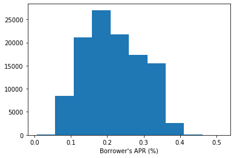

```python
plt.hist(data = loans, x = 'BorrowerAPR')
plt.xlabel('Borrower\'s APR (%)')
plt.show()
```

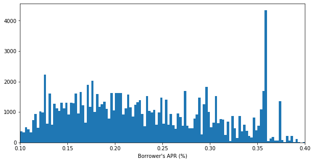

```python
# investigating further on an even smaller bin size
bins = np.arange(0, loans['BorrowerAPR'].max()+0.0025,0.0025)
plt.figure(figsize=[10, 5])
plt.hist(data = loans, x = 'BorrowerAPR', bins=bins)
plt.xlim(0.1,0.4)
plt.xlabel('Borrower\'s APR (%)')
plt.show()
```

Borrower's APR seem to have a relevant frequency of distribution starting on 0.10 until 0.40 with a large spike around 0.35. In this case the small bin size proves very illuminating.

Next up, I will look variables related to the loan: loan original amount, loan monthly payment, term and loan category

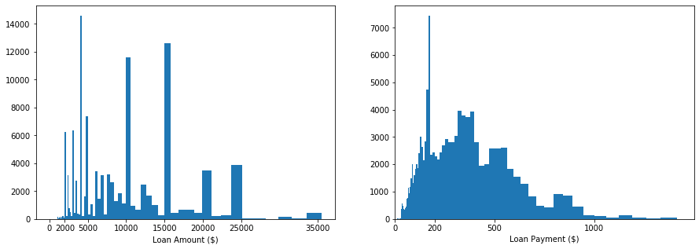

```python
plt.figure(figsize = [15, 5]) # larger figure size for subplots

# example of somewhat too-large bin size
plt.subplot(1, 2, 1) # 1 row, 2 cols, subplot 1
log_binsize = 0.025
bins = 10 ** np.arange(0, np.log10(loans['LoanOriginalAmount'].max())+log_binsize, log_binsize)
plt.hist(data = loans, x = 'LoanOriginalAmount', bins=bins)
plt.xlabel('Loan Amount ($)')
tick_locs = [0, 2000, 5000, 10000,15000, 20000, 25000, 35000]
plt.xticks(tick_locs,tick_locs)

plt.subplot(1, 2, 2) # 1 row, 2 cols, subplot 1
log_binsize = 0.025
bins = 10 ** np.arange(0, np.log10(loans['MonthlyLoanPayment'].max())+log_binsize, log_binsize)
plt.hist(data = loans, x = 'MonthlyLoanPayment', bins=bins)
plt.xlabel('Loan Payment ($)')
tick_locs = [0, 200, 500, 1000]
plt.xticks(tick_locs,tick_locs)
plt.xlim(0,1500);
```

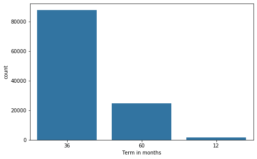

```python
base_color = sb.color_palette()[0]
order = loans['Term'].value_counts().index
plt.figure(figsize=[8, 5])
sb.countplot(data = loans, x = 'Term', color = base_color, order = order)
plt.xlabel('Term in months');
```

The Loan Original Amounts values appear to have a standard value as the distribution peaks concentrates around certain numbers. Payment term is standard in 12, 36 and 60 months and the average monthly payment is around 272 dollars.

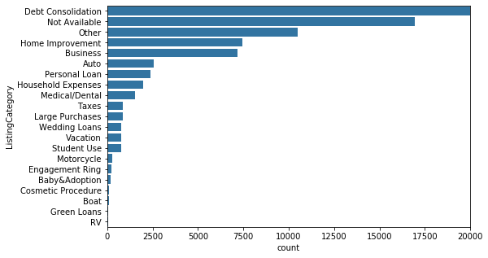

```python
default_color = sb.color_palette()[0]
plt.figure(figsize=[8, 5])
order = loans['ListingCategory'].value_counts().index
sb.countplot(data = loans, y = 'ListingCategory', color = default_color, order = order)
plt.xlim(0,20000);
```

I'll now move on to variables related to the financial situation at the moment someone goes to ask for a loan:

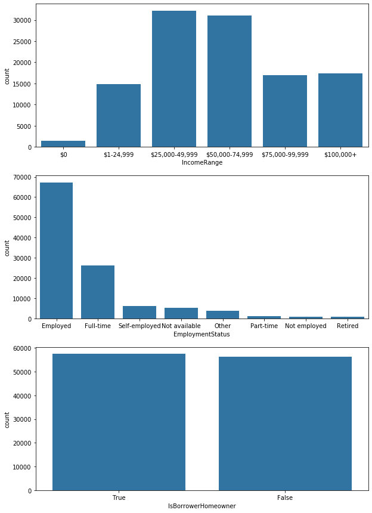

```python
fig, ax = plt.subplots(nrows=3, figsize = [10,15])

default_color = sb.color_palette()[0]
sb.countplot(data = loans, x = 'IncomeRange', color = default_color, ax = ax[0])
sb.countplot(data = loans, x = 'EmploymentStatus',
             color = default_color, ax = ax[1], order = loans['EmploymentStatus'].value_counts().index)
sb.countplot(data = loans, x = 'IsBorrowerHomeowner',
             color = default_color, ax = ax[2], order = loans['IsBorrowerHomeowner'].value_counts().index)

plt.show()
```

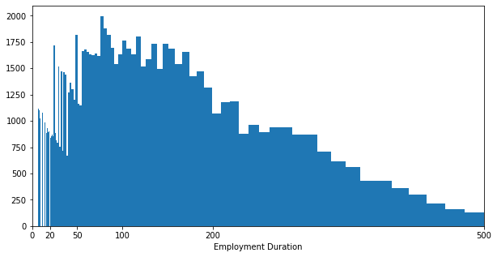

```python
log_binsize = 0.02
bins = 10 ** np.arange(0, np.log10(loans['EmploymentStatusDuration'].max())+log_binsize, log_binsize)
plt.figure(figsize=[10, 5])
plt.hist(data = loans, x = 'EmploymentStatusDuration', bins=bins)
plt.xlabel('Employment Duration')
tick_locs = [0, 20, 50, 100, 200, 500]
plt.xticks(tick_locs,tick_locs)
plt.xlim(0,500);
```

We can conclude from these charts that the majority of borrowers are employed, with salaries ranging from 25,000 to 75,000 and only half of them are homeowners.

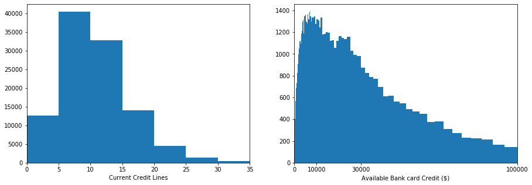

```python
plt.figure(figsize = [15, 5]) # larger figure size for subplots

# example of somewhat too-large bin size
plt.subplot(1, 2, 1) # 1 row, 2 cols, subplot 1
bins = np.arange(0, loans['CurrentCreditLines'].max(),5)
plt.hist(data = loans, x = 'CurrentCreditLines', bins=bins)
plt.xlabel('Current Credit Lines')
plt.xlim(0,35)


plt.subplot(1, 2, 2) # 1 row, 2 cols, subplot 1
log_binsize = 0.025
bins = 10 ** np.arange(0, np.log10(loans['AvailableBankcardCredit'].max())+log_binsize, log_binsize)
plt.hist(data = loans, x = 'AvailableBankcardCredit', bins=bins)
plt.xlabel('Available Bank card Credit ($)')
tick_locs = [0, 10000, 30000, 100000]
plt.xticks(tick_locs,tick_locs)
plt.xlim(0,100000);
```

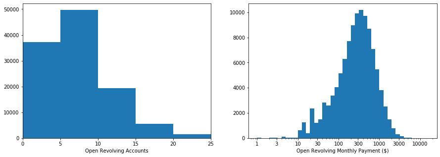

```python
plt.figure(figsize = [15, 5]) # larger figure size for subplots

# example of somewhat too-large bin size
plt.subplot(1, 2, 1) # 1 row, 2 cols, subplot 1
bins = np.arange(0, loans['OpenRevolvingAccounts'].max(),5)
plt.hist(data = loans, x = 'OpenRevolvingAccounts', bins=bins)
plt.xlabel('Open Revolving Accounts')
plt.xlim(0,25)


plt.subplot(1, 2, 2) # 1 row, 2 cols, subplot 1
log_binsize = 0.1
bins = 10 ** np.arange(0, np.log10(loans['OpenRevolvingMonthlyPayment'].max())+log_binsize, log_binsize)
plt.hist(data = loans, x = 'OpenRevolvingMonthlyPayment', bins=bins)
plt.xlabel('Open Revolving Monthly Payment ($)')
plt.xscale('log')
tick_locs = [1, 3, 10, 30, 100, 300, 1000, 3000, 10000]
plt.xticks(tick_locs,tick_locs);
```

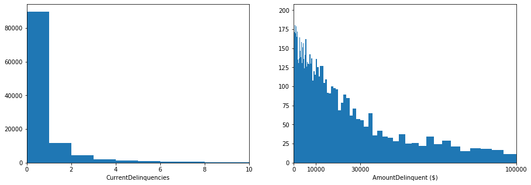

```python
plt.figure(figsize = [15, 5]) # larger figure size for subplots

# example of somewhat too-large bin size
plt.subplot(1, 2, 1) # 1 row, 2 cols, subplot 1
bins = np.arange(0, loans['CurrentDelinquencies'].max(),1)
plt.hist(data = loans, x = 'CurrentDelinquencies', bins=bins)
plt.xlabel('CurrentDelinquencies')
plt.xlim(0,10)


plt.subplot(1, 2, 2) # 1 row, 2 cols, subplot 1
log_binsize = 0.025
bins = 10 ** np.arange(0, np.log10(loans['AmountDelinquent'].max())+log_binsize, log_binsize)
plt.hist(data = loans, x = 'AmountDelinquent', bins=bins)
plt.xlabel('AmountDelinquent ($)')
tick_locs = [0, 10000, 30000, 100000, 300000]
plt.xticks(tick_locs,tick_locs)
plt.xlim(0,100000);
```

These variables present a large part of their values at zero and the rest are spread over a wide range and will not help us in the analysis.

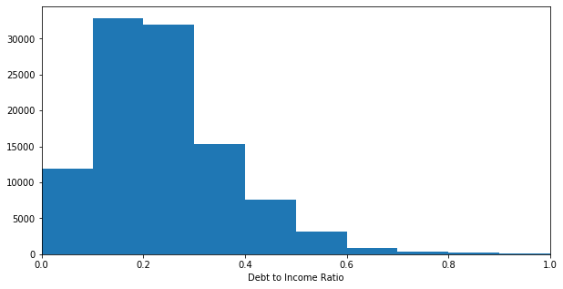

```python
bins = np.arange(0, loans['DebtToIncomeRatio'].max()+0.1,0.1)
plt.figure(figsize=[10, 5])
plt.hist(data = loans, x = 'DebtToIncomeRatio', bins=bins)
plt.xlim(0,1)
plt.xlabel('Debt to Income Ratio')
plt.show()
```

The debt level of people who have loans is low, less than a half of their income. This can have a positive relationship with loan rates.

### Discuss the distribution(s) of your variable(s) of interest. Were there any unusual points? Did you need to perform any transformations?

> As I'm working with financial variables and they have large ranges of values, I look at the data using a log transformation. Another variable that I use the same method was the employment duration. Beside these variables, others have large ranges of values and I had to ajust the axes on charts using *xlim()*. I found an outlier at DebtToIncomeRatio (value around 10), for me the range should be from 0 to 1, for now I will see if this will affect the analysis.

### Of the features you investigated, were there any unusual distributions? Did you perform any operations on the data to tidy, adjust, or change the form of the data? If so, why did you do this?

> At the beginning of this project to prepare the data, as the dataframe has 81 columns and not all data was in necessary format, I droped columns that would not be used and droped the NA values of the variable of interest (BorrowerAPR). I categorize some IncomeRange that were not following the financial category and changed the ListingCategory number to its caption. Regarding distributions, the two variables of Delinquencies have most part of their values equal to zero and the rest is spread in a long range. It seems to me that the both will not help us in this analysis.

## Bivariate Exploration

> To start off with, I want to look at the pairwise correlations present between features in the data.

```python
numeric_vars = ['BorrowerAPR', 'EmploymentStatusDuration', 'CurrentCreditLines',
                'OpenRevolvingAccounts', 'OpenRevolvingMonthlyPayment',
                'CurrentDelinquencies', 'AmountDelinquent', 'AvailableBankcardCredit',
                'DebtToIncomeRatio','LoanOriginalAmount','MonthlyLoanPayment']
categoric_vars = ['Term', 'EmploymentStatus', 'IsBorrowerHomeowner', 'IncomeRange', 'ListingCategory']
```

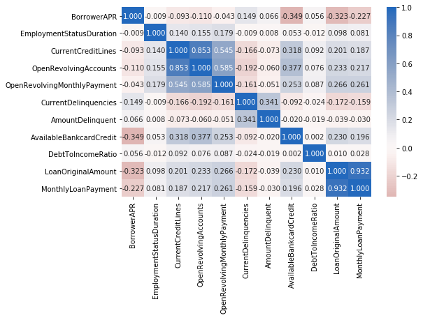

```python
# correlation plot
plt.figure(figsize = [8, 5])
sb.heatmap(loans[numeric_vars].corr(), annot = True, fmt = '.3f',
           cmap = 'vlag_r', center = 0)
plt.show()
```

Your variable of interest(BorrowerAPR) has a negative moderate correlation with AvailableBankcardCredit, LoanOriginalAmount and MonthlyLoanPayment.

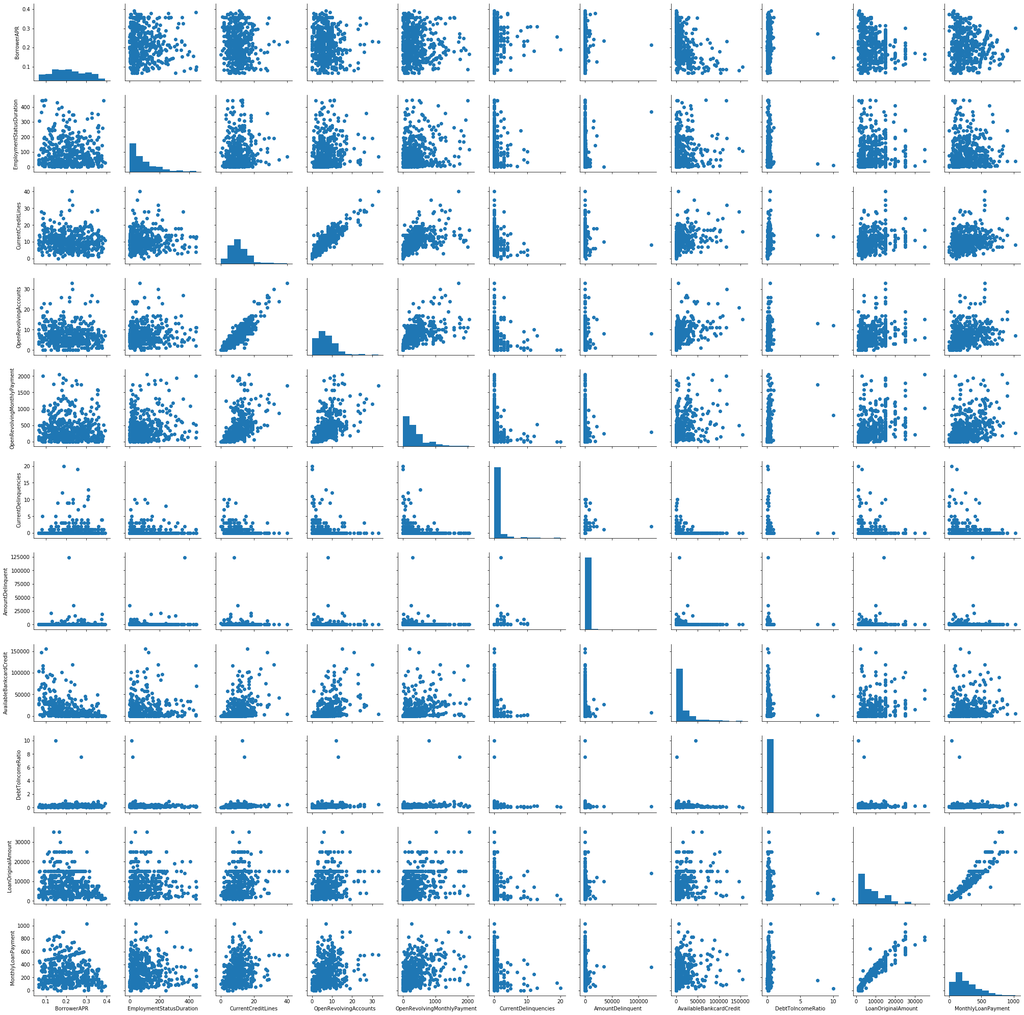

```python
# To render fast, plot a matrix with data sample of 500 loans
samples = np.random.choice(loans.shape[0], 500, replace = False)
loans_samp = loans.loc[samples,:]

g = sb.PairGrid(data = loans_samp, vars = numeric_vars)
g = g.map_diag(plt.hist)
g.map_offdiag(plt.scatter);
```

Regardig this matrix, I can't have any different insight, for better understanding I will only let the variables with correlation with BorrowerAPR.

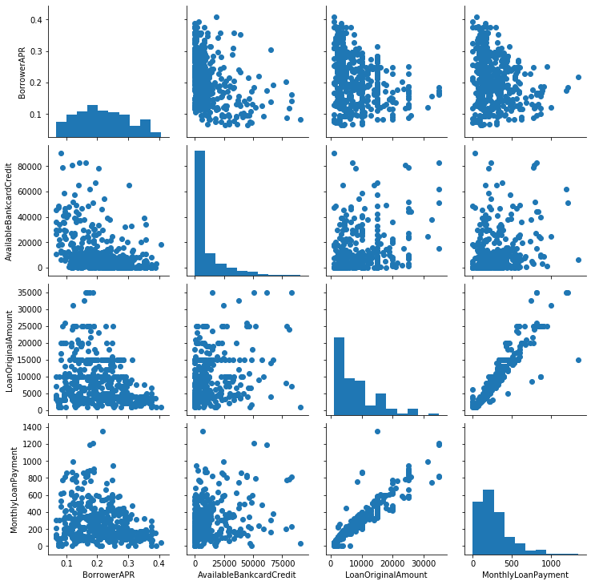

```python
numeric_vars = ['BorrowerAPR', 'AvailableBankcardCredit', 'LoanOriginalAmount','MonthlyLoanPayment']
samples = np.random.choice(loans.shape[0], 500, replace = False)
loans_samp = loans.loc[samples,:]

g = sb.PairGrid(data = loans_samp, vars = numeric_vars)
g = g.map_diag(plt.hist)
g.map_offdiag(plt.scatter);
```

This plot confirm that there isn't a high correlation between Borrower APR and other variables. There is only a hight positive correlation between LoanOriginalAmount and MonthlyLoanPayment.

```python
# compute the logarithm of price to make multivariate plotting easier
def log_trans(x, inverse = False):
    """ quick function for computing log and power operations """
    if not inverse:
        return np.log10(x)
    else:
        return np.power(10, x)

loans['LogLoanAmount'] = loans['LoanOriginalAmount'].apply(log_trans)
```

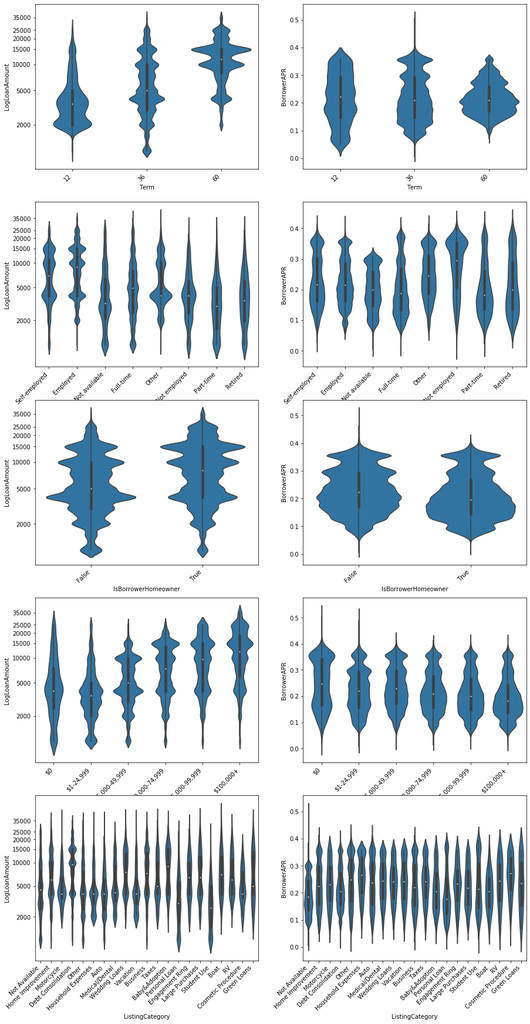

```python
# plot the categorical variables against LoanOriginalAmount and BorrowerAPR again
fig, ax = plt.subplots(ncols = 2, nrows = 5 , figsize = [15,30])

for i in range(len(categoric_vars)):
    var = categoric_vars[i]
    sb.violinplot(data = loans, x = var, y = 'LogLoanAmount', ax = ax[i,0],
               color = default_color)
    ax[i,0].set_yticks(log_trans(np.array([2000, 5000, 10000,15000, 20000, 25000, 35000])))
    ax[i,0].set_yticklabels([2000, 5000, 10000,15000, 20000, 25000, 35000])
    ax[i,0].set_xticklabels(ax[i,0].get_xticklabels(), rotation=45, horizontalalignment='right')
    sb.violinplot(data = loans, x = var, y = 'BorrowerAPR', ax = ax[i,1],
               color = default_color)
    ax[i,1].set_xticklabels(ax[i,1].get_xticklabels(), rotation=45, horizontalalignment='right')

plt.show()
```

According to this chart, on average, long-term loans are better for a larger number of loans, but interest rates do not change much. As I thought, employed people, with their own homes and with high income have access to better values and rates of loans.

### Talk about some of the relationships you observed in this part of the investigation. How did the feature(s) of interest vary with other features in the dataset?

> Expected relationships were found in the association between BorrowerAPR and financial situation at the moment someone goes to ask for a loan (EmploymentStatus, IsBorrowerHomeowner, IncomeRange), the same relation was found with LoanOriginalAmount. A small negative correlation was observed between BorrowerAPR and LoanOriginalAmount, any other variables did not show other relationships of interest.

### Did you observe any interesting relationships between the other features (not the main feature(s) of interest)?

> A high correlation was observed between LoanOriginalAmount and MonthlyLoanPayment but it was expected as the both variables is related.

## Multivariate Exploration

> Create plots of three or more variables to investigate your data even further. Make sure that your investigations are justified, and follow from your work in the previous sections.

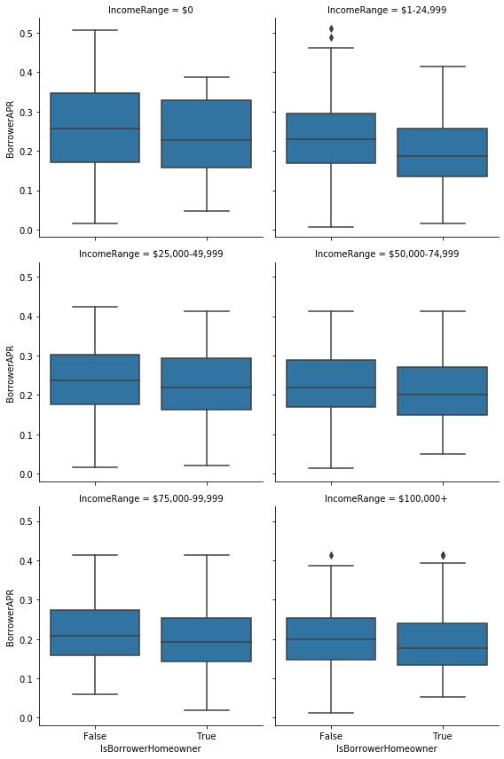

```python
g = sb.FacetGrid(data = loans, col = 'IncomeRange', height = 4, col_wrap= 2)
g.map(sb.boxplot, 'IsBorrowerHomeowner', 'BorrowerAPR');
```

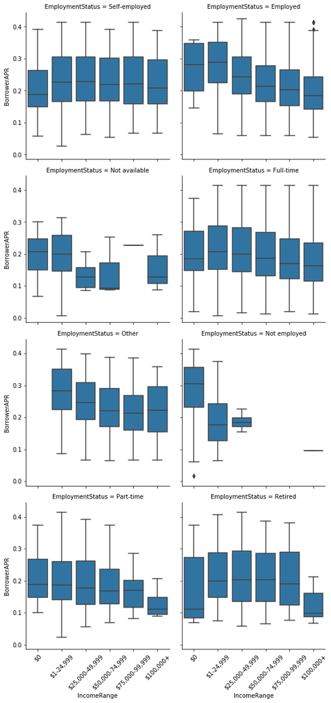

```python
g = sb.FacetGrid(data = loans, col = 'EmploymentStatus', height = 4, col_wrap= 2)
g.map(sb.boxplot, 'IncomeRange', 'BorrowerAPR')
g.set_xticklabels(rotation=45);
```

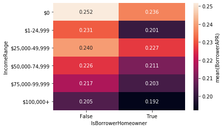

```python
loan_mean = loans.groupby(['IsBorrowerHomeowner', 'IncomeRange']).mean()['BorrowerAPR']
loan_mean = loan_mean.reset_index(name = 'MeanBorrowerAPR')
loan_mean = loan_mean.pivot(index = 'IncomeRange', columns = 'IsBorrowerHomeowner',
                            values = 'MeanBorrowerAPR')
sb.heatmap(loan_mean, annot = True, fmt = '.3f',
           cbar_kws = {'label' : 'mean(BorrowerAPR)'});
```

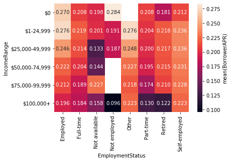

```python
loan_mean = loans.groupby(['EmploymentStatus', 'IncomeRange']).mean()['BorrowerAPR']
loan_mean = loan_mean.reset_index(name = 'MeanBorrowerAPR')
loan_mean = loan_mean.pivot(index = 'IncomeRange', columns = 'EmploymentStatus',
                            values = 'MeanBorrowerAPR')
sb.heatmap(loan_mean, annot = True, fmt = '.3f',
           cbar_kws = {'label' : 'mean(BorrowerAPR)'});
```

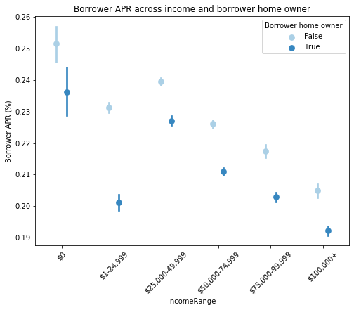

```python
fig = plt.figure(figsize = [8,6])
ax = sb.pointplot(data = loans, x = 'IncomeRange', y = 'BorrowerAPR', hue = 'IsBorrowerHomeowner',
           palette = 'Blues', linestyles = '', dodge = 0.2)
plt.title('Borrower APR across income and borrower home owner')
plt.ylabel('Borrower APR (%)')
plt.xticks(rotation=45)
ax.legend(title = 'Borrower home owner')
plt.show();
```

People who is house owner has lower borrow's rate interest in comparison with other people with the same amount of revenue who is not a house owner. For those that have job the borrow's interest rate decrease according to a higher salary.

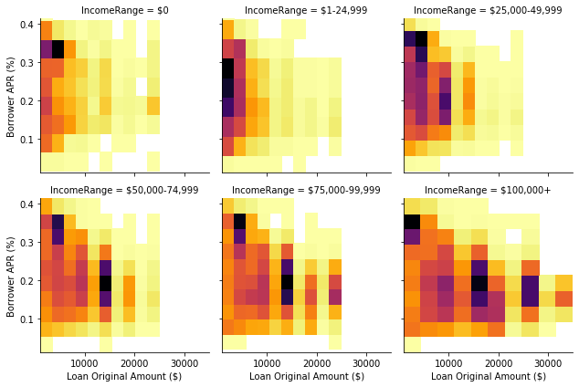

```python
def hist2dgrid(x, y, **kwargs):
    """ Quick hack for creating heat maps with seaborn's PairGrid. """
    palette = kwargs.pop('color')
    plt.hist2d(x, y, cmap = palette, cmin = 1)


g = sb.FacetGrid(data = loans, col = 'IncomeRange', col_wrap = 3, size = 3)
g.map(hist2dgrid, 'LoanOriginalAmount', 'BorrowerAPR', color = 'inferno_r')
g.set_xlabels('Loan Original Amount ($)')
g.set_ylabels('Borrower APR (%)')

plt.show()
```

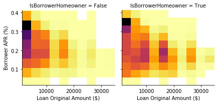

```python
g = sb.FacetGrid(data = loans, col = 'IsBorrowerHomeowner', col_wrap = 3, size = 3)
g.map(hist2dgrid, 'LoanOriginalAmount', 'BorrowerAPR', color = 'inferno_r')
g.set_xlabels('Loan Original Amount ($)')
g.set_ylabels('Borrower APR (%)')

plt.show()
```

These plots confirm that a person who is home owner will have better borrower's APR interest rates and access to a higher loan amounts as much as their income increases.

### Talk about some of the relationships you observed in this part of the investigation. Were there features that strengthened each other in terms of looking at your feature(s) of interest?

> I extended my investigation to discover what features affect the borrower's APR interest rate based on my discoveries in the last session and I confirmed my first tought that person who is home owner will have better borrower's APR interest rates and access to a higher loan amounts as much as their income increases.

### Were there any interesting or surprising interactions between features?

> The fact that surprised me was not finding any relevant correlation between borrower's APR interest and the numeric variables that I selected.